# Optional Stopping

Carolin Kirsch

```r
knitr::opts_chunk$set(message = FALSE, warning = FALSE)

library(tidyverse)
library(flextable)
library(apa7)
library(ftExtra)

set_flextable_defaults(theme_fun = theme_apa,
                        font.family = "Times New Roman")
```

```r
# fixed design constants of the UBELIX run (must match optstop_function_run_sim.R;
# checked against the raw data below whenever the raw data is loaded)
n_iterations <- 30000L
alpha <- 0.05
```

Note: the raw per-iteration outputs (`results_UBELIX/sim_optstop_*_30000iterations.rds`) are large, git-ignored and NOT distributed. They are only loaded when one of the cached summary files below is missing; regenerate them with `optstop_function_run_sim.R` in that case. With all summary files present (as shipped), this document knits without the raw data.

```r
sim_optstop_nmax_summary_file <- paste0("results_UBELIX/sim_optstop_nmax_summary_",n_iterations,"iterations.rds")
sim_optstop_nmin_summary_file <- paste0("results_UBELIX/sim_optstop_nmin_summary_",n_iterations,"iterations.rds")
optstop_peek_counts_nmax_file <- paste0("results_UBELIX/sim_optstop_nmax_peek_counts_summary_",n_iterations,"iterations.rds")
optstop_peek_counts_nmin_file <- paste0("results_UBELIX/sim_optstop_nmin_peek_counts_summary_",n_iterations,"iterations.rds")
optstop_peeks_at_stop_nmax_file <- paste0("results_UBELIX/sim_optstop_nmax_peeks_at_stop_summary_",n_iterations,"iterations.rds")

raw_needed <- !all(file.exists(c(sim_optstop_nmax_summary_file,
                                 sim_optstop_nmin_summary_file,
                                 optstop_peek_counts_nmax_file,
                                 optstop_peek_counts_nmin_file,
                                 optstop_peeks_at_stop_nmax_file)))

if (raw_needed) {
  sim_optstop_nmax <- readRDS(paste0("results_UBELIX/sim_optstop_nmax_",n_iterations,"iterations.rds"))
  sim_optstop_nmin <- readRDS(paste0("results_UBELIX/sim_optstop_nmin_",n_iterations,"iterations.rds"))

  # check the constants above against the raw data
  stopifnot(max(sim_optstop_nmax$iteration) == n_iterations,
            sim_optstop_nmax$alpha[1] == alpha)

  sim_optstop_nmin <- bind_rows(
    sim_optstop_nmin,
    # add the four conditions that shared between the sets and only estimated once
    sim_optstop_nmax |> filter(n_max == 300)
  )
}
```

# replication

## table nmax

Note: this chunk only recomputes and saves the summary if `results_UBELIX/sim_optstop_nmax_summary_<n_iterations>iterations.rds` does not already exist; otherwise the existing file is loaded.

```r
if (!file.exists(sim_optstop_nmax_summary_file)) {
  sim_optstop_nmax_summary <- sim_optstop_nmax |>
    unnest(reported_result) |>
    group_by(n_max, k, count_peeks_hypothetical) |>
    summarize(
      empirical_detection_rate  = mean(p_value < alpha),
      empirical_detection_rate_mcse = sqrt(empirical_detection_rate * (1 - empirical_detection_rate) / n()),
      .groups = "drop"
      )

  saveRDS(sim_optstop_nmax_summary, sim_optstop_nmax_summary_file)
} else {
  sim_optstop_nmax_summary <- readRDS(sim_optstop_nmax_summary_file)
}

sim_optstop_nmax_summary
```

```
## # A tibble: 16 × 5
##    n_max     k count_peeks_hypothetical empirical_detection_rate
##    <dbl> <dbl>                    <int>                    <dbl>
##  1    30     1                       26                   0.219
##  2    30     5                        6                   0.156
##  3    30    10                        3                   0.118
##  4    30    50                        2                   0.0941
##  5    50     1                       46                   0.267
##  6    50     5                       10                   0.200
##  7    50    10                        5                   0.152
##  8    50    50                        2                   0.0936
##  9   100     1                       96                   0.326
## 10   100     5                       20                   0.257
## 11   100    10                       10                   0.214
## 12   100    50                        2                   0.0943
## 13   300     1                      296                   0.411
## 14   300     5                       60                   0.345
## 15   300    10                       30                   0.298
## 16   300    50                        6                   0.181
## # ℹ 1 more variable: empirical_detection_rate_mcse <dbl>
```

```r
sim_optstop_nmax_summary |>
  mutate(`maximum n per condition` = as.character(n_max),
         `step size` = as.character(k)) |>
  mutate(across(where(is.numeric), \(x) scales::number(x, accuracy = 0.001))) |>
  mutate(edr_string = paste0(empirical_detection_rate,
                             " (",
                             empirical_detection_rate_mcse,
                             ")")) |>
  select(`maximum n per condition`,
         `step size`,
         edr_string) |>
  pivot_wider(names_from = `step size`,
              values_from = edr_string) |>
  column_spanner_label("step size", -1) |>
  apa_flextable(no_format_columns = `maximum n per condition`) |>
  align(j = 1, align = "center") |>
  add_footer_lines(values = as_paragraph(as_i("Note. "), "Empirical False Positive Rate (±1 Monte Carlo Standard Error)."))
```

| maximum n per condition | step size 1 | step size 5 | step size 10 | step size 50 |
| --- | --- | --- | --- | --- |
| 30 | 0.219 (0.002) | 0.156 (0.002) | 0.118 (0.002) | 0.094 (0.002) |
| 50 | 0.267 (0.003) | 0.200 (0.002) | 0.152 (0.002) | 0.094 (0.002) |
| 100 | 0.326 (0.003) | 0.257 (0.003) | 0.214 (0.002) | 0.094 (0.002) |
| 300 | 0.411 (0.003) | 0.345 (0.003) | 0.298 (0.003) | 0.181 (0.002) |

Note. Empirical False Positive Rate (±1 Monte Carlo Standard Error).

## table nmin

Note: this chunk only recomputes and saves the summary if `results_UBELIX/sim_optstop_nmin_summary_<n_iterations>iterations.rds` does not already exist; otherwise the existing file is loaded.

```r
if (!file.exists(sim_optstop_nmin_summary_file)) {
  sim_optstop_nmin_summary <- sim_optstop_nmin |>
    unnest(reported_result) |>
    group_by(n_min, k, count_peeks_hypothetical) |>
    summarize(
      empirical_detection_rate  = mean(p_value < alpha),
      empirical_detection_rate_mcse = sqrt(empirical_detection_rate * (1 - empirical_detection_rate) / n()),
      .groups = "drop"
      )

  saveRDS(sim_optstop_nmin_summary, sim_optstop_nmin_summary_file)
} else {
  sim_optstop_nmin_summary <- readRDS(sim_optstop_nmin_summary_file)
}

sim_optstop_nmin_summary
```

```
## # A tibble: 16 × 5
##    n_min     k count_peeks_hypothetical empirical_detection_rate
##    <dbl> <dbl>                    <int>                    <dbl>
##  1     5     1                      296                    0.411
##  2     5     5                       60                    0.345
##  3     5    10                       30                    0.298
##  4     5    50                        6                    0.181
##  5    30     1                      271                    0.304
##  6    30     5                       55                    0.266
##  7    30    10                       28                    0.238
##  8    30    50                        6                    0.165
##  9    50     1                      251                    0.264
## 10    50     5                       51                    0.236
## 11    50    10                       26                    0.216
## 12    50    50                        6                    0.156
## 13   100     1                      201                    0.202
## 14   100     5                       41                    0.177
## 15   100    10                       21                    0.170
## 16   100    50                        5                    0.126
## # ℹ 1 more variable: empirical_detection_rate_mcse <dbl>
```

```r
sim_optstop_nmin_summary |>
  mutate(`initial n per condition` = as.character(n_min),
         `step size` = as.character(k)) |>
  mutate(across(where(is.numeric), \(x) scales::number(x, accuracy = 0.001))) |>
  mutate(edr_string = paste0(empirical_detection_rate,
                             " (",
                             empirical_detection_rate_mcse,
                             ")")) |>
  select(`initial n per condition`,
         `step size`,
         edr_string) |>
  pivot_wider(names_from = `step size`,
              values_from = edr_string) |>
  column_spanner_label("step size", -1) |>
  apa_flextable(no_format_columns = `initial n per condition`) |>
  align(j = 1, align = "center") |>
  add_footer_lines(values = as_paragraph(as_i("Note. "), "Empirical False Positive Rate (±1 Monte Carlo Standard Error)."))
```

| initial n per condition | step size 1 | step size 5 | step size 10 | step size 50 |
| --- | --- | --- | --- | --- |
| 5 | 0.411 (0.003) | 0.345 (0.003) | 0.298 (0.003) | 0.181 (0.002) |
| 30 | 0.304 (0.003) | 0.266 (0.003) | 0.238 (0.002) | 0.165 (0.002) |
| 50 | 0.264 (0.003) | 0.235 (0.002) | 0.216 (0.002) | 0.156 (0.002) |
| 100 | 0.202 (0.002) | 0.177 (0.002) | 0.170 (0.002) | 0.126 (0.002) |

Note. Empirical False Positive Rate (±1 Monte Carlo Standard Error).

## plot nmax

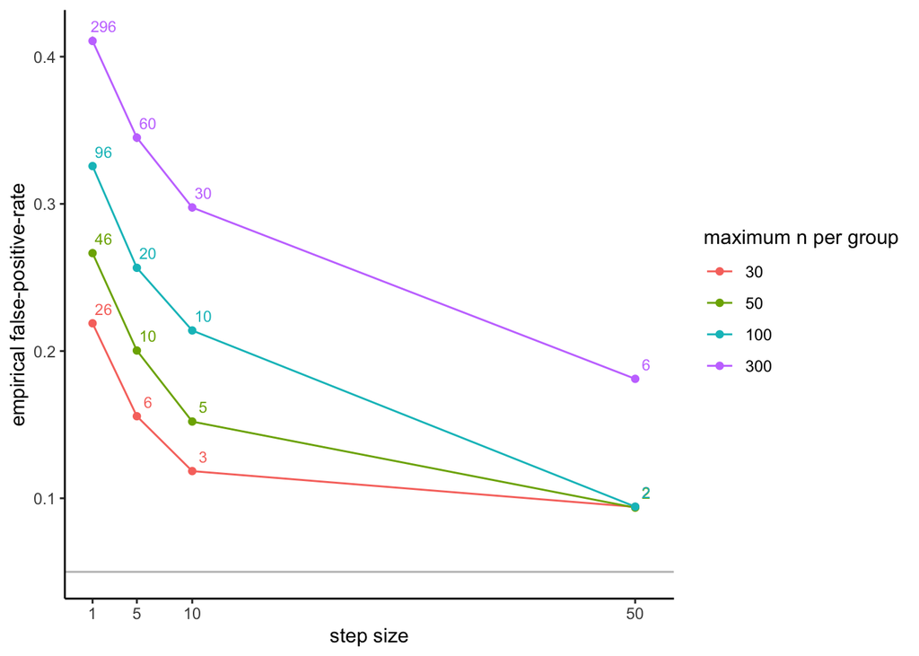

```r
ggplot(sim_optstop_nmax_summary,
       aes(x = k,
           y = empirical_detection_rate,
           color = as.factor(n_max))) +
  geom_hline(yintercept = alpha, col = "grey") +
  geom_linerange(aes(ymin = empirical_detection_rate - empirical_detection_rate_mcse,
                     ymax = empirical_detection_rate + empirical_detection_rate_mcse)
                , color = "black") +
  geom_line() +
  geom_point() +
  geom_text(aes(label = count_peeks_hypothetical),
            nudge_x = 1, vjust = -0.8, size = 3,
            show.legend = FALSE) +
  #scale_y_continuous(breaks = c(0, 0.05, 0.1, 0.2, 0.3, 0.4), limits = c(0,0.45)) +
  scale_x_continuous(breaks = c(1, 5, 10, 50)) +
  labs(
    x = "step size",
    y = "empirical false-positive-rate",
    color = "maximum n per group") +
  theme_classic()
```

*Note.* Lineranges show ±1 Monte Carlo standard error (MCSE) of the empirical false-positive rate and are largely smaller than the plotted points; maximum MCSE across all conditions = .003.

## plot nmin

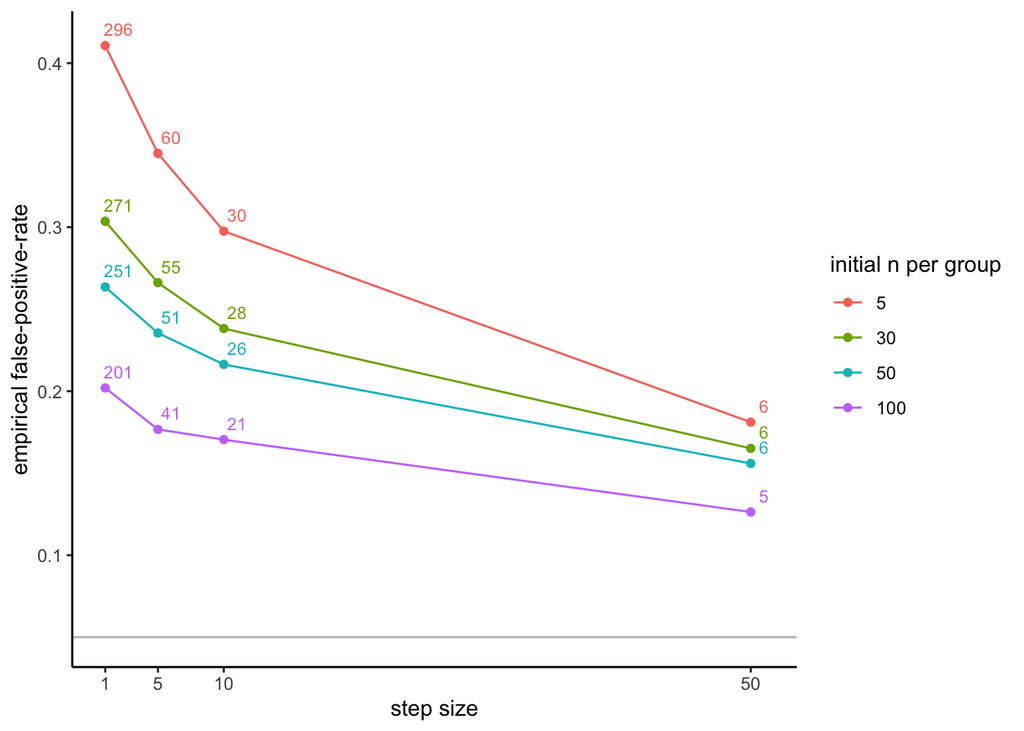

```r
ggplot(sim_optstop_nmin_summary,
       aes(x = k,
           y = empirical_detection_rate,
           color = as.factor(n_min))) +
  geom_hline(yintercept = alpha, col = "grey") +
  geom_linerange(aes(ymin = empirical_detection_rate - empirical_detection_rate_mcse,
                     ymax = empirical_detection_rate + empirical_detection_rate_mcse)
                , color = "black") +
  geom_line() +
  geom_point() +
  geom_text(aes(label = count_peeks_hypothetical),
            nudge_x = 1, vjust = -0.8, size = 3,
            show.legend = FALSE) +
  #scale_y_continuous(breaks = c(0, 0.05, 0.1, 0.2, 0.3, 0.4), limits = c(0,0.45)) +
  scale_x_continuous(breaks = c(1, 5, 10, 50)) +
  labs(
    x = "step size",
    y = "empirical false-positive-rate",
    color = "initial n per group") +
  theme_classic()
```

*Note.* Lineranges show ±1 Monte Carlo standard error (MCSE) of the empirical false-positive rate and are largely smaller than the plotted points; maximum MCSE across all conditions = .003.

# extension

## span of FPR

```r
sim_optstop_nmin_summary |>
  group_by(k) |>
  summarize(span = max(empirical_detection_rate) - min(empirical_detection_rate))
```

```
## # A tibble: 4 × 2
##       k   span
##   <dbl>  <dbl>
## 1     1 0.209
## 2     5 0.168
## 3    10 0.127
## 4    50 0.0548
```

```r
sim_optstop_nmax_summary |>
  group_by(k) |>
  summarize(FPR_span = max(empirical_detection_rate) - min(empirical_detection_rate))
```

```
## # A tibble: 4 × 2
##       k FPR_span
##   <dbl>    <dbl>
## 1     1   0.192
## 2     5   0.189
## 3    10   0.179
## 4    50   0.0875
```

## hypothetical peeks

### count hypothetical peeks

Note: these chunks only recompute and save the peek-count summaries from the raw data if the cached file does not already exist; otherwise the existing file is loaded.

```r
if (!file.exists(optstop_peek_counts_nmax_file)) {
  optstop_peek_counts_nmax <- sim_optstop_nmax |>
    unnest(reported_result) |>
    group_by(k) |>
    count(count_peeks_hypothetical, .drop = FALSE) |>
    mutate(n = n/n_iterations) |>
    rename(count = n)

  saveRDS(optstop_peek_counts_nmax, optstop_peek_counts_nmax_file)
} else {
  optstop_peek_counts_nmax <- readRDS(optstop_peek_counts_nmax_file)
}

optstop_peek_counts_nmax
```

```
## # A tibble: 14 × 3
## # Groups:   k [4]
##        k count_peeks_hypothetical count
##    <dbl>                    <int> <dbl>
##  1     1                       26     1
##  2     1                       46     1
##  3     1                       96     1
##  4     1                      296     1
##  5     5                        6     1
##  6     5                       10     1
##  7     5                       20     1
##  8     5                       60     1
##  9    10                        3     1
## 10    10                        5     1
## 11    10                       10     1
## 12    10                       30     1
## 13    50                        2     3
## 14    50                        6     1
```

```r
if (!file.exists(optstop_peek_counts_nmin_file)) {
  optstop_peek_counts_nmin <- sim_optstop_nmin |>
    unnest(reported_result) |>
    group_by(k) |>
    count(count_peeks_hypothetical, .drop = FALSE) |>
    mutate(n = n/n_iterations) |>
    rename(count = n)

  saveRDS(optstop_peek_counts_nmin, optstop_peek_counts_nmin_file)
} else {
  optstop_peek_counts_nmin <- readRDS(optstop_peek_counts_nmin_file)
}

optstop_peek_counts_nmin
```

```
## # A tibble: 14 × 3
## # Groups:   k [4]
##        k count_peeks_hypothetical count
##    <dbl>                    <int> <dbl>
##  1     1                      201     1
##  2     1                      251     1
##  3     1                      271     1
##  4     1                      296     1
##  5     5                       41     1
##  6     5                       51     1
##  7     5                       55     1
##  8     5                       60     1
##  9    10                       21     1
## 10    10                       26     1
## 11    10                       28     1
## 12    10                       30     1
## 13    50                        5     1
## 14    50                        6     3
```

### linear x-axis

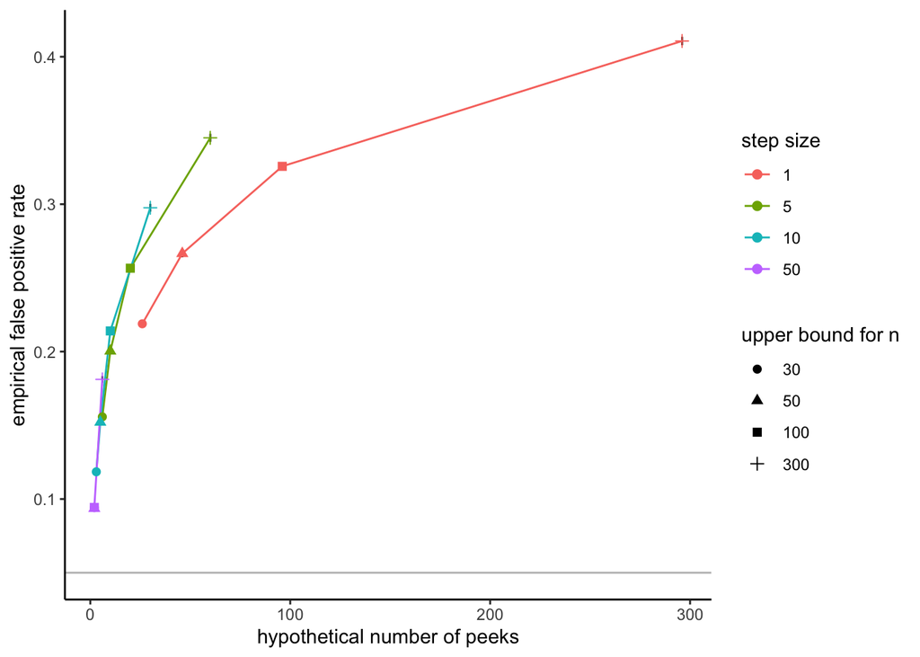

```r
ggplot(sim_optstop_nmax_summary,
       aes(x = count_peeks_hypothetical, y = empirical_detection_rate)) +
  geom_hline(yintercept = alpha, colour = "grey") +
  geom_linerange(aes(ymin = empirical_detection_rate - empirical_detection_rate_mcse,
                     ymax = empirical_detection_rate + empirical_detection_rate_mcse)
                , color = "black") +
  geom_line(aes(colour = as.factor(k), group = as.factor(k))) +
  geom_point(aes(colour = as.factor(k), shape = as.factor(n_max)), size = 2) +
  labs(x = "hypothetical number of peeks",
       y = "empirical false positive rate",
       colour = "step size",
       shape = "upper bound for n") +
  theme_classic()
```

*Note.* Lineranges show ±1 Monte Carlo standard error (MCSE) of the empirical false-positive rate and are largely smaller than the plotted points; maximum MCSE across all conditions = .003.

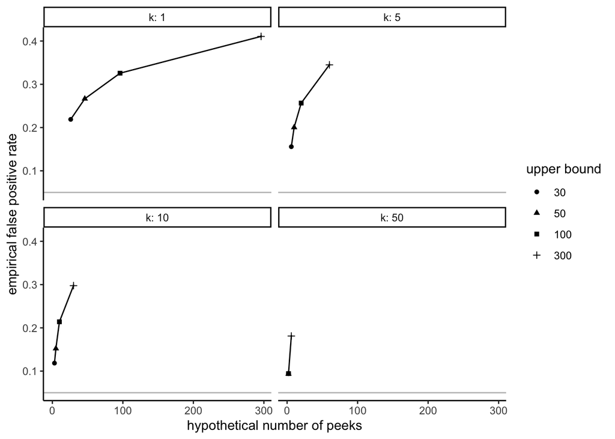

```r
ggplot(sim_optstop_nmax_summary,
       aes(x = count_peeks_hypothetical, y = empirical_detection_rate)) +
    geom_hline(yintercept = alpha, colour = "grey") +
    geom_linerange(aes(ymin = empirical_detection_rate - empirical_detection_rate_mcse,
                       ymax = empirical_detection_rate + empirical_detection_rate_mcse)
                  , color = "black") +
    geom_line() +
    geom_point(aes(shape = as.factor(n_max))) +
    facet_wrap(vars(k), nrow = 2, labeller = label_both) +  # nrow = 1 => nebeneinander
    labs(x = "hypothetical number of peeks", y = "empirical false positive rate",
         shape = "upper bound") +
    theme_classic()
```

*Note.* Lineranges show ±1 Monte Carlo standard error (MCSE) of the empirical false-positive rate and are largely smaller than the plotted points; maximum MCSE across all conditions = .003.

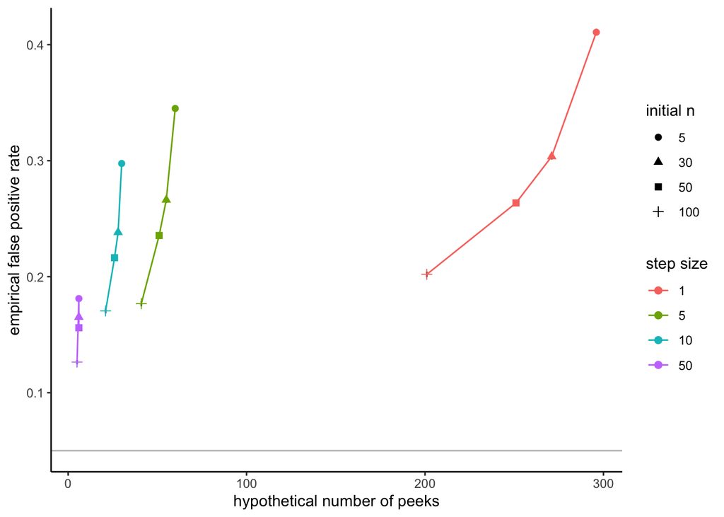

```r
ggplot(sim_optstop_nmin_summary,
       aes(x = count_peeks_hypothetical, y = empirical_detection_rate)) +
  geom_hline(yintercept = alpha, colour = "grey") +
  geom_linerange(aes(ymin = empirical_detection_rate - empirical_detection_rate_mcse,
                     ymax = empirical_detection_rate + empirical_detection_rate_mcse)
                , color = "black") +
  geom_line(aes(colour = as.factor(k), group = as.factor(k))) +
  geom_point(aes(colour = as.factor(k), shape = as.factor(n_min)), size = 2) +
  labs(x = "hypothetical number of peeks",
       y = "empirical false positive rate",
       colour = "step size",
       shape = "initial n") +
  theme_classic()
```

*Note.* Lineranges show ±1 Monte Carlo standard error (MCSE) of the empirical false-positive rate and are largely smaller than the plotted points; maximum MCSE across all conditions = .003.

### facet plot

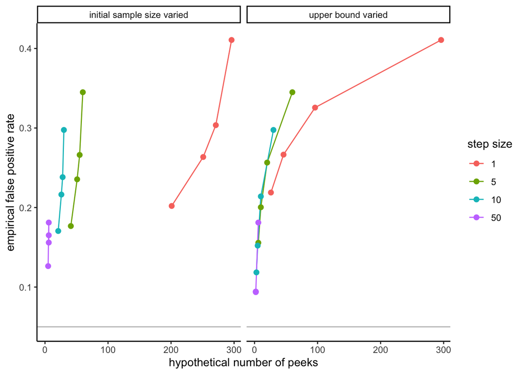

```r
peeks_cells <- bind_rows(
  sim_optstop_nmax_summary |>
    mutate(dataset = "upper bound varied"),
  sim_optstop_nmin_summary |>
    mutate(dataset = "initial sample size varied")
)

ggplot(peeks_cells,
       aes(x = count_peeks_hypothetical, y = empirical_detection_rate,
           colour = as.factor(k), group = as.factor(k))) +
  geom_hline(yintercept = alpha, colour = "grey") +
  geom_linerange(aes(ymin = empirical_detection_rate - empirical_detection_rate_mcse,
                     ymax = empirical_detection_rate + empirical_detection_rate_mcse)
                , color = "black") +
  geom_line() +
  geom_point(size = 2) +
  facet_wrap(~ dataset) +
  labs(x = "hypothetical number of peeks",
       y = "empirical false positive rate",
       colour = "step size") +
  theme_classic()
```

*Note.* Lineranges show ±1 Monte Carlo standard error (MCSE) of the empirical false-positive rate and are largely smaller than the plotted points; maximum MCSE across all conditions = .003.

## actual peeks in FP results

Note: this chunk only recomputes and saves the summary from the raw data if the cached file does not already exist; otherwise the existing file is loaded.

```r
if (!file.exists(optstop_peeks_at_stop_nmax_file)) {
  optstop_peeks_at_stop_nmax <- sim_optstop_nmax |>
    unnest(reported_result) |>
    filter(p_value < alpha) |>
    group_by(count_peeks_hypothetical) |>
    summarize(peeks_median = median(count_peeks_stop))

  saveRDS(optstop_peeks_at_stop_nmax, optstop_peeks_at_stop_nmax_file)
} else {
  optstop_peeks_at_stop_nmax <- readRDS(optstop_peeks_at_stop_nmax_file)
}

optstop_peeks_at_stop_nmax
```

```
## # A tibble: 12 × 2
##    count_peeks_hypothetical peeks_median
##                       <int>        <dbl>
##  1                        2            1
##  2                        3            2
##  3                        5            2
##  4                        6            2
##  5                       10            3
##  6                       20            4
##  7                       26            6
##  8                       30            5
##  9                       46            8
## 10                       60            7
## 11                       96           12
## 12                      296           22
```